# IODS course project

## Data manipulation

Now we will standardize the dataset and print out summaries of the scaled data. All the variables now now have the mean 0.

```r
# center and standardize variables
boston_scaled <- scale(Boston)

# summaries of the scaled variables
summary(boston_scaled)
```

```
##       crim                 zn               indus
##  Min.   :-0.419367   Min.   :-0.48724   Min.   :-1.5563
##  1st Qu.:-0.410563   1st Qu.:-0.48724   1st Qu.:-0.8668
##  Median :-0.390280   Median :-0.48724   Median :-0.2109
##  Mean   : 0.000000   Mean   : 0.00000   Mean   : 0.0000
##  3rd Qu.: 0.007389   3rd Qu.: 0.04872   3rd Qu.: 1.0150
##  Max.   : 9.924110   Max.   : 3.80047   Max.   : 2.4202
##       chas              nox                rm               age
##  Min.   :-0.2723   Min.   :-1.4644   Min.   :-3.8764   Min.   :-2.3331
##  1st Qu.:-0.2723   1st Qu.:-0.9121   1st Qu.:-0.5681   1st Qu.:-0.8366
##  Median :-0.2723   Median :-0.1441   Median :-0.1084   Median : 0.3171
##  Mean   : 0.0000   Mean   : 0.0000   Mean   : 0.0000   Mean   : 0.0000
##  3rd Qu.:-0.2723   3rd Qu.: 0.5981   3rd Qu.: 0.4823   3rd Qu.: 0.9059
##  Max.   : 3.6648   Max.   : 2.7296   Max.   : 3.5515   Max.   : 1.1164
##       dis               rad               tax             ptratio
##  Min.   :-1.2658   Min.   :-0.9819   Min.   :-1.3127   Min.   :-2.7047
##  1st Qu.:-0.8049   1st Qu.:-0.6373   1st Qu.:-0.7668   1st Qu.:-0.4876
##  Median :-0.2790   Median :-0.5225   Median :-0.4642   Median : 0.2746
##  Mean   : 0.0000   Mean   : 0.0000   Mean   : 0.0000   Mean   : 0.0000
##  3rd Qu.: 0.6617   3rd Qu.: 1.6596   3rd Qu.: 1.5294   3rd Qu.: 0.8058
##  Max.   : 3.9566   Max.   : 1.6596   Max.   : 1.7964   Max.   : 1.6372
##      black             lstat              medv
##  Min.   :-3.9033   Min.   :-1.5296   Min.   :-1.9063
##  1st Qu.: 0.2049   1st Qu.:-0.7986   1st Qu.:-0.5989
##  Median : 0.3808   Median :-0.1811   Median :-0.1449
##  Mean   : 0.0000   Mean   : 0.0000   Mean   : 0.0000
##  3rd Qu.: 0.4332   3rd Qu.: 0.6024   3rd Qu.: 0.2683
##  Max.   : 0.4406   Max.   : 3.5453   Max.   : 2.9865
```

```r
# class of the boston_scaled object
class(boston_scaled)
```

```
## [1] "matrix"
```

```r
# change the object to data frame
boston_scaled <- as.data.frame(boston_scaled)
```

Now we create a categorical variable of the scaled crime rate, by using the quantiles as the break points. Thus we have 4 categories: **low**, **med_low**, **med_high** and **high**. After we create the new categorical varable, we add it to the dataset and remove the continous crim variable.

```r
# summary of the scaled crime rate
summary(boston_scaled$crim)
```

```
##      Min.   1st Qu.    Median      Mean   3rd Qu.      Max.
## -0.419367 -0.410563 -0.390280  0.000000  0.007389  9.924110
```

```r
# create a quantile vector of crim and print it
bins <- quantile(boston_scaled$crim)
bins
```

```
##           0%          25%          50%          75%         100%
## -0.419366929 -0.410563278 -0.390280295  0.007389247  9.924109610
```

```r
# create a categorical variable 'crime'
crime <- cut(boston_scaled$crim, breaks = bins, include.lowest = TRUE, label=c("low", "med_low", "med_high", "high"))

# look at the table of the new factor crime
table(crime)
```

```
## crime
##      low  med_low med_high     high
##      127      126      126      127
```

```r
# remove original crim from the dataset
boston_scaled <- dplyr::select(boston_scaled, -crim)

# add the new categorical value to scaled data
boston_scaled <- data.frame(boston_scaled, crime)
```

Further on, we divide the dataset to train and test sets, so that 80% of the data belongs to the train set.

```r
# boston_scaled is available

# number of rows in the Boston dataset
n <- nrow(boston_scaled)

# choose randomly 80% of the rows
ind <- sample(n,  size = n * 0.8)

# create train set
train <- boston_scaled[ind,]

# create test set
test <- boston_scaled[-ind,]

# save the correct classes from test data
correct_classes <- test$crime

# remove the crime variable from test data
test <- dplyr::select(test, -crime)
```

## Linear discriminant analysis

Now we perform Linear Discriminant Analysis on the train set. We are using the categorical crime rate as the target variable and all the other variables in the dataset as predictor variables.

```r
# linear discriminant analysis
lda.fit <- lda(crime ~ ., data = train)

# print the lda.fit object
lda.fit
```

```
## Call:
## lda(crime ~ ., data = train)
##
## Prior probabilities of groups:
##       low   med_low  med_high      high
## 0.2549505 0.2475248 0.2524752 0.2450495
##
## Group means:
##                  zn      indus         chas        nox         rm
## low       0.8573535 -0.8655449 -0.119431971 -0.8371475  0.4045023
## med_low  -0.1172105 -0.2955502  0.003267949 -0.5709906 -0.1543008
## med_high -0.3846714  0.1464204  0.190859195  0.3768430  0.1292129
## high     -0.4872402  1.0171737 -0.153023000  1.0416932 -0.4299050
##                 age        dis        rad        tax     ptratio
## low      -0.8360940  0.8345657 -0.6941969 -0.7287973 -0.34629433
## med_low  -0.3837065  0.3652176 -0.5477507 -0.4864042  0.01130116
## med_high  0.3770431 -0.3753927 -0.4436680 -0.3488025 -0.34264516
## high      0.8081080 -0.8551141  1.6375616  1.5136504  0.78011702
##                black       lstat        medv
## low       0.38084265 -0.74397510  0.46376032
## med_low   0.31622336 -0.13029761 -0.02215984
## med_high  0.07126539 -0.05302454  0.23734427
## high     -0.84039701  0.87125482 -0.68285419
##
## Coefficients of linear discriminants:
##                 LD1         LD2        LD3
## zn       0.12178437  0.65093099 -0.9938387
## indus    0.03903643 -0.21346844  0.3184413
## chas    -0.02816703 -0.03587799  0.1063747
## nox      0.41460918 -0.81010490 -1.2329799
## rm      -0.01217076 -0.03886161 -0.1437874
## age      0.19861481 -0.29921485 -0.2080057
## dis     -0.09464714 -0.24155824  0.1913606
## rad      3.68072049  0.93510601 -0.2570615
## tax      0.04132156 -0.08156008  0.6090666
## ptratio  0.14603549  0.04043056 -0.2122595
## black   -0.09078290  0.03827291  0.1018833
## lstat    0.18092446 -0.19911060  0.4953801
## medv     0.08529366 -0.47540061 -0.1146785
##
## Proportion of trace:
##    LD1    LD2    LD3
## 0.9620 0.0276 0.0104
```

The results (linear combination of the variables that separate the target variable class) can be also seen in the plot:

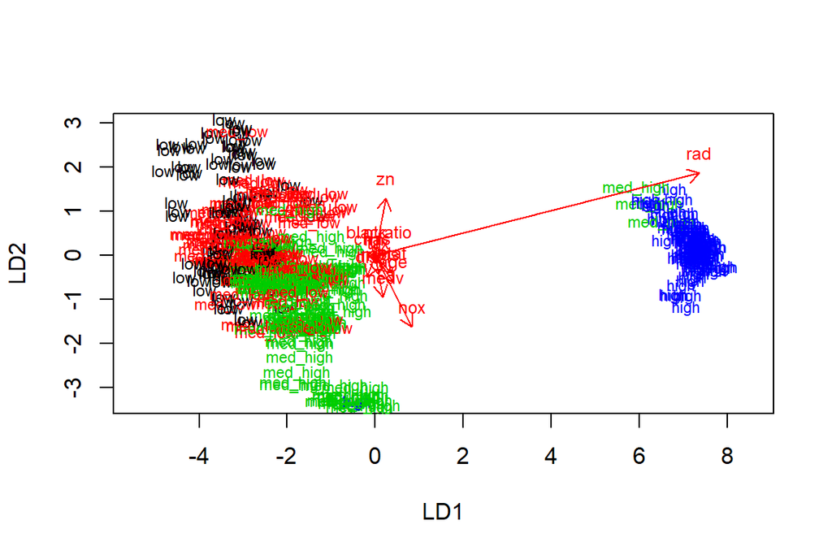

```r
# the function for lda biplot arrows
lda.arrows <- function(x, myscale = 1, arrow_heads = 0.1, color = "red", tex = 0.75, choices = c(1,2)){
  heads <- coef(x)
  arrows(x0 = 0, y0 = 0,
         x1 = myscale * heads[,choices[1]],
         y1 = myscale * heads[,choices[2]], col=color, length = arrow_heads)
  text(myscale * heads[,choices], labels = row.names(heads),
       cex = tex, col=color, pos=3)
}

# target classes as numeric
classes <- as.numeric(train$crime)

# plot the lda results
plot(lda.fit, dimen = 2, col = classes, pch = classes)
lda.arrows(lda.fit, myscale = 2)
```

## Predict the classes with the LDA model

Now we will predict the classes with the LDA model on the previously prepared test data. Also we will cross tabulate the results with the crime categories from the test set.

```r
# predict classes with test data
lda.pred <- predict(lda.fit, newdata = test)

# cross tabulate the results
table(correct = correct_classes, predicted = lda.pred$class)
```

```
##           predicted
## correct    low med_low med_high high
##   low       18       6        0    0
##   med_low    7      16        3    0
##   med_high   1       7       13    3
##   high       0       0        0   28
```

The diagonal of the table shows us the number of the correct results, while other cells show the number of mistakes:

**high** was every time classfied correctly (28).